# Latent Dirichlet Allocation on MeSH Terms

Jason Baik

12/30/2018

## Introduction

MeSH (Medical Subject Headings) are terms from the [National Library of Medicine’s vocabularly](http://research.library.gsu.edu/c.php?g=115556&p=753156).

The dataset I’ll be working with is extracted from [ClinicalTrials.gov](https://clinicaltrials.gov/), “a database of privately and publicly funded clinical studies conducted around the world”. I grabbed it from PostgreSQL database using the `DBI` package, which connects to [AACT](https://aact.ctti-clinicaltrials.org/), a public database that contains information from ClinicalTrials.gov. For simplicity, I wrapped the steps needed to extract data from this database in a package called aactr

Nick Giangreco, a Columbia PhD student, introduced me to this database. Along with Nick, I contacted the administrators of this database at Duke University, Sheri Tibbs and Karen Chiswell. Thankfully, they had categorized these MeSH terms and agreed to share this with me. Below, I import, clean, and save the excel file into `tagged_mesh_terms`

```r
# Import and clean data
tagged_mesh_terms <- read_excel("2010_tagged_mesh_and_free_text_terms.xlsx",
                                sheet = 3) %>%
  janitor::clean_names() %>%
  select(-c(term_type, identifier)) %>%
  mutate(term = str_to_title(term))
```

```
## readxl works best with a newer version of the tibble package.
## You currently have tibble v1.4.2.
## Falling back to column name repair from tibble <= v1.4.2.
## Message displays once per session.
```

Now, I want to work with only the available MeSH terms from AACT that the Duke researchers had categorized. Subsequently, I `inner_join`ed `tagged_mesh_terms` and `browse_conditions`.

```r
browse_conditions_filtered <- browse_conditions %>%
  select(nct_id, mesh_term) %>%
  inner_join(tagged_mesh_terms, by = c("mesh_term" = "term")) %>%
  select(-clinical_domain)
```

Around 44% of the MeSH terms in `browse_conditions` joined with `tagged_mesh_terms`. That’s alot higher than I expected. Let’s use these terms in our LDA algorithm and set K = 10 since `tagged_mesh_terms` has 10 unique tags (clinical domains). I’m following this [vignette from the tidytext package](https://cran.r-project.org/web/packages/tidytext/vignettes/topic_modeling.html)

```r
browse_conditions_filtered_counts <- browse_conditions_filtered %>%
  count(nct_id, mesh_term, sort = TRUE) %>%
  ungroup()

# Create DocumentTermMatrix in order to put dataset into the LDA algorithm from the topicmodels package
browse_conditions_dtm <- browse_conditions_filtered_counts %>%
  cast_dtm(nct_id, mesh_term, n)

# This take a few minutes
topic_lda <- topicmodels::LDA(browse_conditions_dtm, k = 10, control = list(seed = 1234))

# Use the broom package to mutate beta, the probability of that term being generated from that topic.
topic_lda_tidy <- tidy(topic_lda)

# Use top_n() to find top 5 terms within each topic
top_mesh_terms <- topic_lda_tidy %>%
    group_by(topic) %>%
    top_n(5, beta) %>%
    ungroup() %>%
    arrange(topic, -beta)
```

Visualization. We look at 5 topics at a time so that the graphs fit in our window.

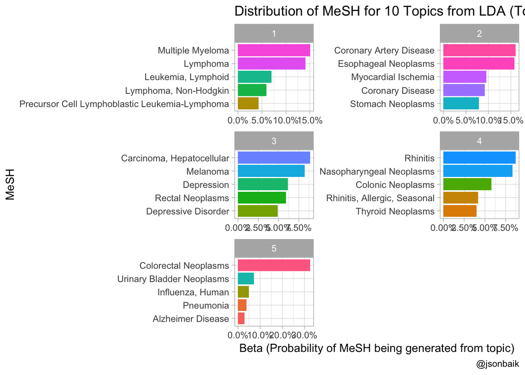

```r
# First 5 topics
top_mesh_terms %>%
  filter(topic %in% c(1:5)) %>%
  mutate(term = reorder(term, beta)) %>%
  ggplot(aes(term, beta, fill = term)) +
  geom_bar(stat = "identity", show.legend = FALSE) +
  facet_wrap(~ topic, scales = "free", nrow = 3) +
  coord_flip() +
  scale_y_continuous(labels = scales::percent_format()) +
  labs(x = "MeSH",
       y = "Beta (Probability of MeSH being generated from topic)",
       caption = "@jsonbaik") +
  ggtitle("Distribution of MeSH for 10 Topics from LDA (Topics 1~5)")
```

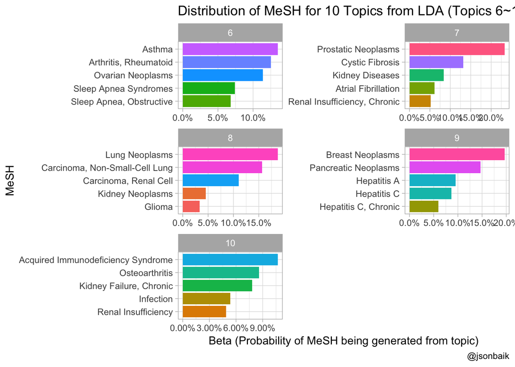

```r
# First 5 topics
top_mesh_terms %>%
  filter(topic %in% c(6:10)) %>%
  mutate(term = reorder(term, beta)) %>%
  ggplot(aes(term, beta, fill = term)) +
  geom_bar(stat = "identity", show.legend = FALSE) +
  facet_wrap(~ topic, scales = "free", nrow = 3) +
  coord_flip() +
  scale_y_continuous(labels = scales::percent_format()) +
  labs(x = "MeSH",
       y = "Beta (Probability of MeSH being generated from topic)",
       caption = "@jsonbaik") +
  ggtitle("Distribution of MeSH for 10 Topics from LDA (Topics 6~10)")
```

```r
check_ground_truth <- function(topic_number) {

  topic_term <- top_mesh_terms %>%
    filter(topic == topic_number) %>%
    select(term) %>%
    pull()

tagged_mesh_terms %>%
  filter(term %in% topic_term) %>%
  count(clinical_domain, sort = TRUE)
}
```

```r
ground_truth <- map(c(1:10), check_ground_truth)
```